# ggplot2 geometric functions

NATASHA UMULISA RUTAGENGWA

2026-10-29

# 1 Introduction

ggplot2 geometric functions, usually called geoms. In R you use them to choose how your data should be displayed

typical ggplot2 graph follows this structure:

library(ggplot2)

ggplot(data, aes(x = variable_1, y=variable_2 ) + geom_function()

Let’s apply all the ggplot2 functions to a practical Human Resource Management (HRM) data.

We will use three important HRM activities:

1. Employed employees: Employees currently working in the institution.
2. Exited employees: Employees who have resigned, retired, been terminated, or otherwise left the institution.
3. Paid employees: Employees whose salaries have been successfully paid for a particular month.

We will also use departments, salaries, employment dates, and payroll information.

# 2 Prepare an HRM dataset in R

First, install and load ggplot2.

```r
# install.packages("ggplot2")
library(ggplot2)
```

Let’s create a sample employee dataset.

```r
employees <- data.frame(
  employee_id = 1:15,

  name = c(
    "Jean", "Peter", "Mary", "David", "Alice",
    "John", "Grace", "Paul", "Sarah", "James",
    "Eric", "Diane", "Joseph", "Anne", "Mark"
  ),

  department = c(
    "IT", "HR", "Finance", "IT", "HR",
    "Finance", "IT", "HR", "Finance", "IT",
    "HR", "Finance", "IT", "HR", "Finance"
  ),

  status = c(
    "Employed", "Employed", "Employed", "Exited", "Employed",
    "Employed", "Exited", "Employed", "Employed", "Exited",
    "Employed", "Employed", "Employed", "Exited", "Employed"
  ),

  salary = c(
    800000, 600000, 750000, 500000, 650000,
    700000, 550000, 620000, 720000, 480000,
    680000, 760000, 850000, 520000, 690000
  ),

  paid = c(
    "Yes", "Yes", "No", "No", "Yes",
    "Yes", "No", "Yes", "No", "No",
    "Yes", "Yes", "Yes", "No", "No"
  )
)

print(employees)
```

```
##    employee_id   name department   status salary paid
## 1            1   Jean         IT Employed 800000  Yes
## 2            2  Peter         HR Employed 600000  Yes
## 3            3   Mary    Finance Employed 750000   No
## 4            4  David         IT   Exited 500000   No
## 5            5  Alice         HR Employed 650000  Yes
## 6            6   John    Finance Employed 700000  Yes
## 7            7  Grace         IT   Exited 550000   No
## 8            8   Paul         HR Employed 620000  Yes
## 9            9  Sarah    Finance Employed 720000   No
## 10          10  James         IT   Exited 480000   No
## 11          11   Eric         HR Employed 680000  Yes
## 12          12  Diane    Finance Employed 760000  Yes
## 13          13 Joseph         IT Employed 850000  Yes
## 14          14   Anne         HR   Exited 520000   No
## 15          15   Mark    Finance Employed 690000   No
```

Our dataset contains:

```r
nrow(employees) # total employees.
```

```
## [1] 15
```

```r
sum(employees$status=='Employed') # sum of employed employees.
```

```
## [1] 11
```

```r
sum(employees$status=='Exited') # sum of exited employees.
```

```
## [1] 4
```

```r
sum(employees$paid=='Yes') # employees marked as paid.
```

```
## [1] 8
```

```r
sum(employees$paid=='No') # employees marked as not paid.
```

```
## [1] 7
```

- 15 employees
- 11 employed employees.
- 4 exited employees.
- 8 employees marked as paid.
- 7 employees marked as not paid.

These are illustrative records, not actual institutional statistics.

# 3 Understanding each graph using HRM examples

## 3.1 geom_bar()

Used to count the number of observations in each category.

e.g: Number of employees by employment status

HRM questions:

How many employees are currently employed and how many exited?

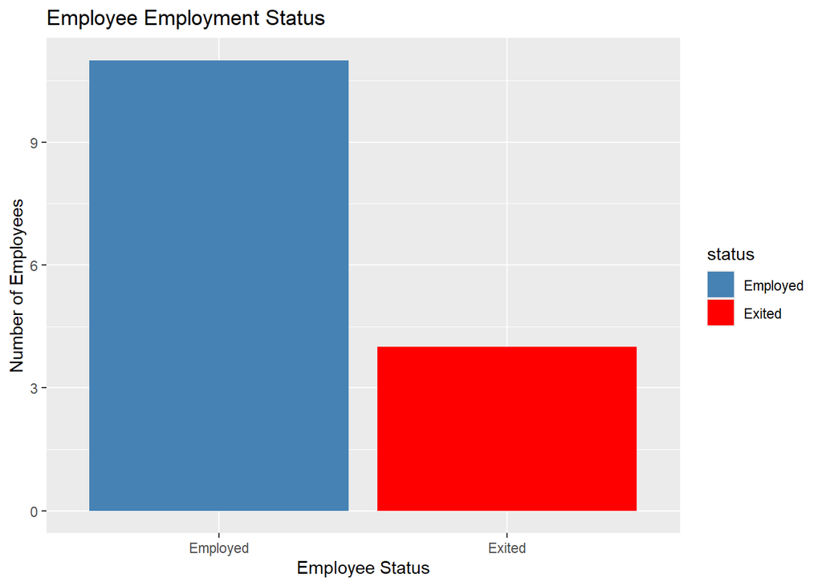

```r
ggplot(employees, aes(x= status, fill=status)) +
  geom_bar() +
  scale_fill_manual(
    values = c("Employed" = "steelblue", "Exited"="red" )
  )+
  labs(
    title = "Employee Employment Status",
    x="Employee Status",
    y = "Number of Employees"
  )
```

- Employed = 11

- Exited = 4

This graph is useful for HR departments when preparing workforce reports.

## 3.2 geom_histogram()

Used to show the distribution of numerical data.

e.g: Distribution of employee salaries

HRM question: How many employees earn salaries within different salary ranges?

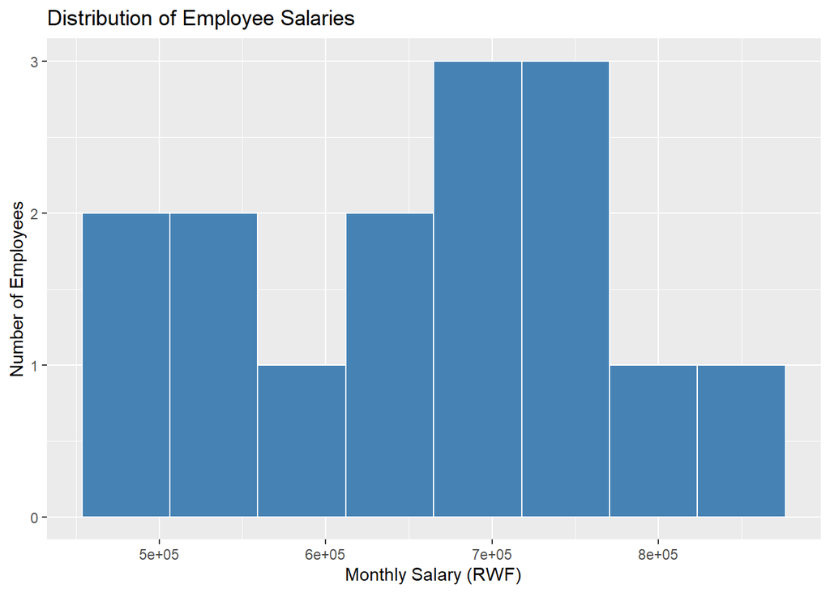

```r
ggplot(employees, aes(x = salary)) +
  geom_histogram(
    bins = 8,
    fill = "steelblue",
    color = "white"
  ) +
  labs(
    title = "Distribution of Employee Salaries",
    x = "Monthly Salary (RWF)",
    y = "Number of Employees"
  )
```

The histogram helps HR understand salary distribution.

For example:

- How many employees earn between 500,000 and 600,000 RWF?
- How many earn between 700,000 and 800,000 RWF?

## 3.3 geom_density()

Similar to a histogram, but displays a smooth distribution curve.

e.g: Salary distribution by employment status

HRM question: How does the salary distribution of employed employees compare with employees who exited?

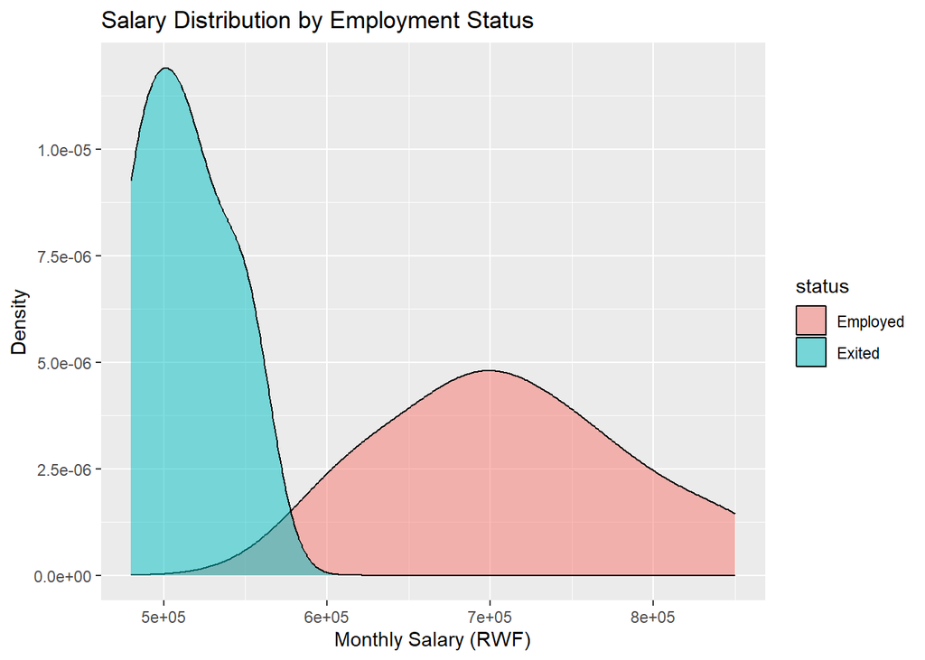

```r
ggplot(employees, aes(x = salary, fill = status)) +
  geom_density(alpha = 0.5) +
  labs(
    title = "Salary Distribution by Employment Status",
    x = "Monthly Salary (RWF)",
    y = "Density"
  )
```

This helps HR compare the salary profiles of current and former employees.

## 3.4 geom_boxplot()

Used to summarize the distribution of numerical data and identify outliers.

e.g: Salary comparison by department

HRM question: Which department has higher salaries, and which department has greater salary variation?

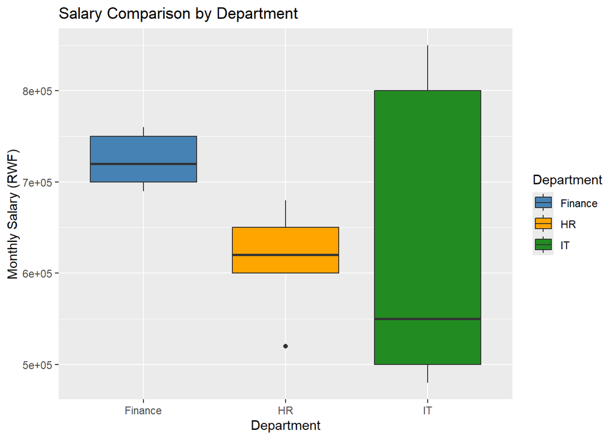

```r
ggplot(employees, aes(
  x = department,
  y = salary,
  fill = department
)) +
  geom_boxplot() +
  scale_fill_manual(values = c(
    "Finance" = "steelblue",
    "HR" = "orange",
    "IT" = "forestgreen"
  )) +
  labs(
    title = "Salary Comparison by Department",
    x = "Department",
    y = "Monthly Salary (RWF)",
    fill = "Department"
  )
```

The boxplot helps identify:

- Median salary in each department.
- Salary variation.
- Potentially unusually high or low salaries (outliers).

HR employees generally earn less than Finance employees. The dot represents an employee whose salary is unusually low compared with the other HR salaries.

IT has the widest salary distribution. This may reflect differences in technical skills, job grades, seniority, responsibilities, or experience.

## 3.5 geom_point()

Used to show the relationship between two numerical variables.

Let’s create an additional variable representing years of service.

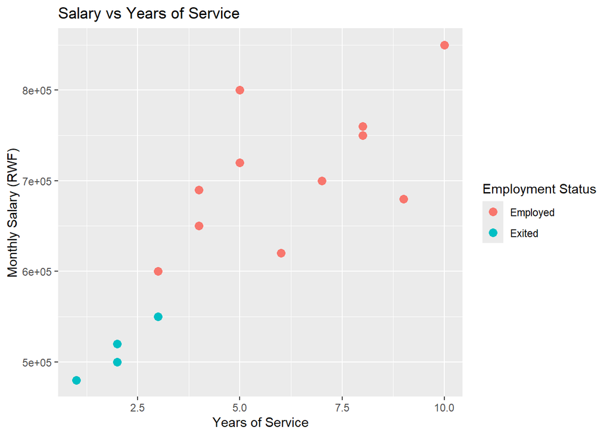

```r
employees$years_service <- c(
  5, 3, 8, 2, 4,
  7, 3, 6, 5, 1,
  9, 8, 10, 2, 4
)

ggplot(employees, aes(x = years_service, y = salary)) +
  geom_point(aes(color = status), size = 3) +

  labs(
    title = "Salary vs Years of Service",
    x = "Years of Service",
    y = "Monthly Salary (RWF)",
    color = "Employment Status"
  )
```

HR can investigate whether employees with more years of service receive higher salaries.

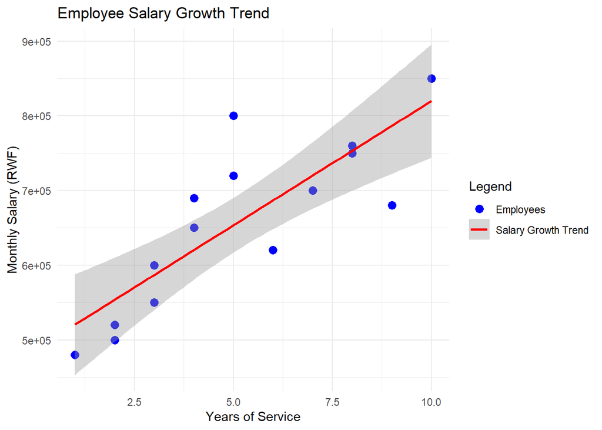

```r
ggplot(employees, aes(x = years_service, y = salary)) +

  geom_point(aes(color = "Employees"), size = 3) +

  geom_smooth(
    aes(color = "Salary Growth Trend", group = 1),
    method = "lm",
    se = TRUE
  ) +

  scale_color_manual(
    name = "Legend",
    values = c(
      "Employees" = "blue",
      "Salary Growth Trend" = "red"
    )
  ) +

  labs(
    title = "Employee Salary Growth Trend",
    x = "Years of Service",
    y = "Monthly Salary (RWF)"
  ) +

  theme_minimal()
```

This shows an association, not proof that additional service years cause salary increases.

## 3.7 geom_jitter()

Sometimes many points have exactly the same position and overlap. geom_jitter() spreads them slightly so you can see them.

e.g: Compare paid and unpaid employees

HRM question: How are salaries distributed among paid and unpaid employees?

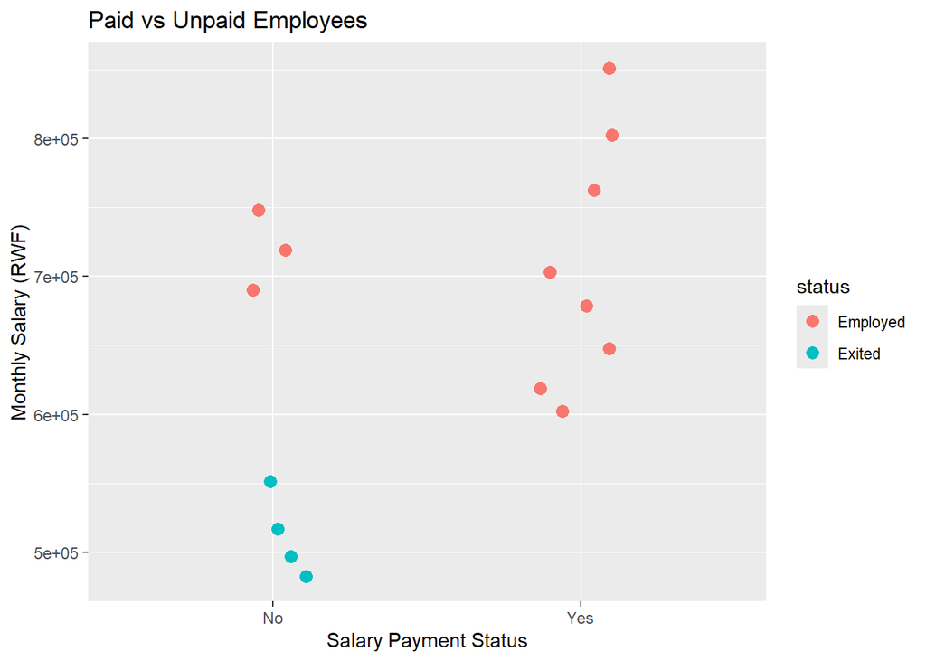

```r
ggplot(employees,
       aes(x = paid, y = salary, color = status)) +

  geom_jitter(
    width = 0.15,
    size = 3
  ) +

  labs(
    title = "Paid vs Unpaid Employees",
    x = "Salary Payment Status",
    y = "Monthly Salary (RWF)"
  )
```

- Yes = employees whose salaries were paid.
- No = employees whose salaries were not paid.
- Each dot represents one employee.

Jitter prevents points with similar values from hiding one another.

This is useful for payroll reconciliation.

## 3.8 geom_violin()

Similar to a boxplot, but shows more detail about the shape of the data distribution.

e.g: Salary distribution across departments

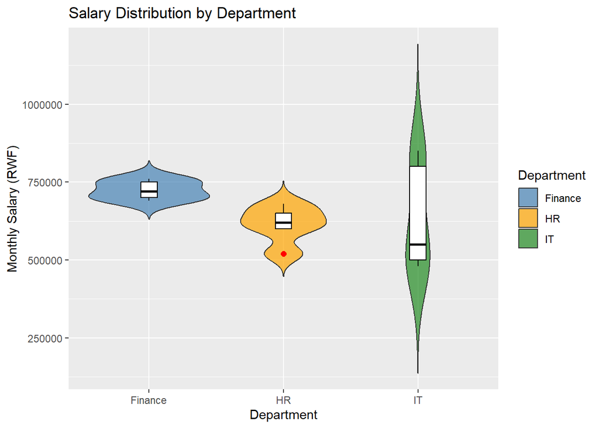

```r
ggplot(employees,
       aes(x = department, y = salary, fill = department)) +

  geom_violin(trim = FALSE, alpha = 0.7) +

  geom_boxplot(
    width = 0.12,
    fill = "white",
    color = "black",
    outlier.color = "red",
    outlier.size = 2
  ) +

  scale_fill_manual(
    name = "Department",
    values = c(
      "Finance" = "steelblue",
      "HR" = "orange",
      "IT" = "forestgreen"
    )
  ) +

  labs(
    title = "Salary Distribution by Department",
    x = "Department",
    y = "Monthly Salary (RWF)"
  )
```

- Wide sections indicate more observations concentrated around those salary levels.
- Narrow sections indicate fewer observations.
- You can compare salary distributions across departments.

## 3.9 geom_text()

Used to add labels or text.

e.g:

Display employee names on a graph

HRM question: Which employees have the highest salaries?

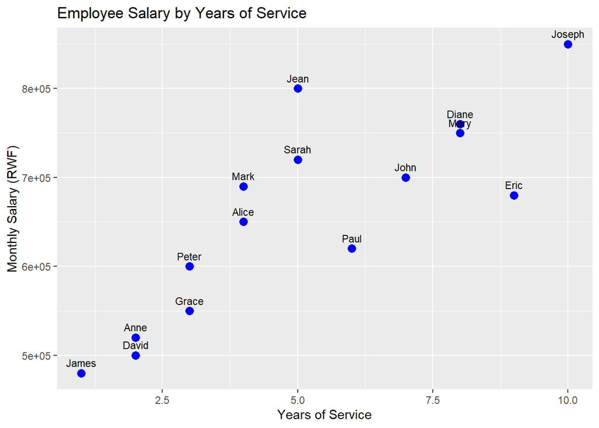

```r
ggplot(employees,
       aes(x = years_service, y = salary)) +

  geom_point(color = "blue", size = 3) +

  geom_text(
    aes(label = name),
    vjust = -0.8,
    size = 3
  ) +

  labs(
    title = "Employee Salary by Years of Service",
    x = "Years of Service",
    y = "Monthly Salary (RWF)"
  )
```

Each point represents an employee, and the text identifies that employee.

Useful for identifying individual employees in HR analytics. In real HR reports, avoid exposing personal information unnecessarily.

## 3.10 geom_rug()

Adds small marks along the axes to show where individual data points are located.

e.g: Show individual employee salaries

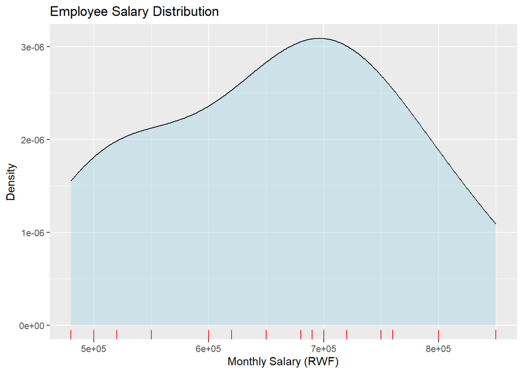

```r
ggplot(employees, aes(x = salary)) +

  geom_density(fill = "lightblue", alpha = 0.5) +

  geom_rug(color = "red") +

  labs(
    title = "Employee Salary Distribution",
    x = "Monthly Salary (RWF)",
    y = "Density"
  )
```

The small red marks along the X-axis represent individual employee salaries.

This helps HR see the actual observations behind the distribution curve.

## 3.11 geom_hline()

Adds a horizontal line at a specific Y value.

e.g: Add a horizontal salary benchmark

HRM question: Which employees earn above or below the salary benchmark of 700,000 RWF?

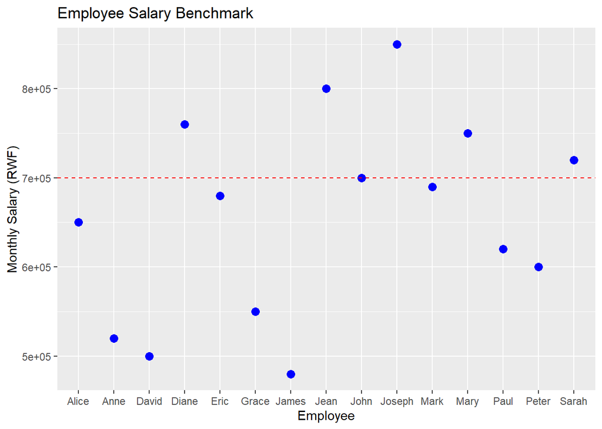

```r
ggplot(employees,
       aes(x = name, y = salary)) +

  geom_point(color = "blue", size = 3) +

  geom_hline(
    yintercept = 700000,
    color = "red",
    linetype = "dashed"
  ) +

  labs(
    title = "Employee Salary Benchmark",
    x = "Employee",
    y = "Monthly Salary (RWF)"
  )
```

- Above the red line: salary greater than 700,000 RWF.

- Below the red line: salary less than 700,000 RWF.
- On the line: salary equal to 700,000 RWF.

This can help HR compare salaries against an established salary threshold.

## 3.12 geom_vline()

Adds a vertical line at a specific X value.

e.g: Add a vertical service-years benchmark

HRM question: Which employees have worked for at least five years?

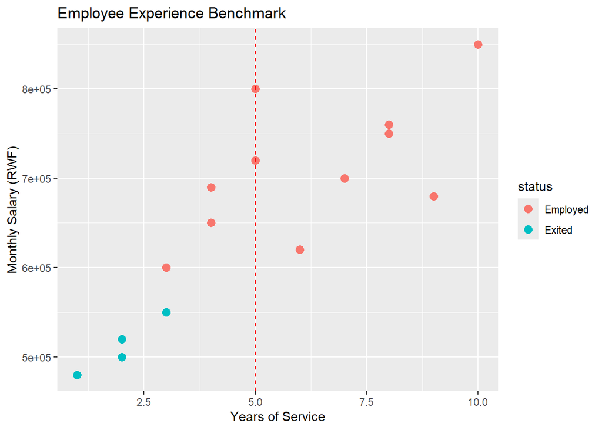

```r
ggplot(employees,
       aes(x = years_service, y = salary)) +

  geom_point(aes(color = status), size = 3) +

  geom_vline(
    xintercept = 5,
    color = "red",
    linetype = "dashed"
  ) +

  labs(
    title = "Employee Experience Benchmark",
    x = "Years of Service",
    y = "Monthly Salary (RWF)"
  )
```

- Left of the line: employees with fewer than five years of service.
- Right of the line: employees with more than five years of service.
- On the line: employees with exactly five years of service.

Useful for analyzing employee experience and eligibility for certain HR programs.

# 4 Summary: HRM requirement vs Recommended function

Count employed vs exited employees: use geom_bar()

Analyze salary ranges: use geom_histogram()

Compare salary distributions: use geom_density()

Identify salary outliers:  
use geom_boxplot()

Analyze salary vs experience: use geom_point()

Analyze salary growth trends: use geom_smooth()

Compare paid vs unpaid employees: use geom_jitter()

Compare salary distributions by department: use geom_violin()

Identify individual employees: use geom_text()

Inspect individual salary observations: use geom_rug()

Compare salaries against a benchmark: use geom_hline()

Compare employee experience against a threshold: use geom_vline()